# Redbanded Rockfish

*Sebastes babcocki*

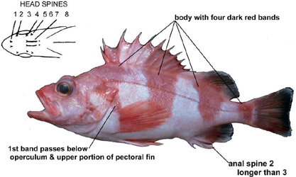

**Body color:** Light pink w/ several broad vertical dark-red bands on body; bands faded in large specimens.

**Peritoneum color:** dark **Shape between eyes:** concave to flat

**Counts:** D:XIII,13-15, Ar:6-8, P1:17-20, GR:29-33, LLp:41-51, LLs:56-64, V:26

**Occurence:** Bering Sea - Southern California

**Depth:** 625 meters **Size:** 56 cm **Species code:** 30475

**Similar species:**

- *Flag rockfish* - first red band stops ventrally at lower edge of operculum; pectoral rays typically 17 (typically 19 in Redbanded RF); rare north of San Francisco
- *Tiger rockfish* - all head spines present; body red w/ black or crimson bars; anal spine 2 equal to or shorter than 3
- *Treefish* - body dark olive dorsally, yellowish ventrally w/ 5-6 black-olive bands; head spine 8 present
- *Shortraker rockfish* - body typically uniform pink to orange-pink occasionally w/ faint darker red bands above lateral line; head spine count differs; anal spine 2 shorter than 3; peritoneum light w/ black dots; lateral line pores 28-32 (41-51 in Redbanded RF)

Back to Group

**Corrections:** If you see mistakes or want to suggest changes, please create an [issue](https://github.com/zoyafuso-NOAA/RACE_Survey_App/issues) on the source repository or

*reach out to Liz Dawson (Liz.Dawson AT noaa.gov).*